### Part II

#### Solution

Tuesday, May 21, 2013

**2.** Fortune magazine publishes a list of the world’s billionaires each year. The 1992 list includes 233 individuals. Their wealth, age, and geographic location (Asia, Europe, Middle East, United States, and Other) are reported. Data can be found in the file `wealthy.csv`.

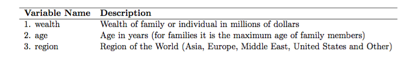

The following SAS code may be helpful to get the data:

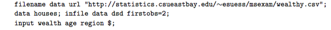

For all of the following parts, you **must include and pertinent SAS code** for full credit.

1. Use Box-Cox to determine if a transformation is necessary on the response, `wealth`. Based on this estimation, write out the full **first**-order additive model with dummy variables.  
   **Solution**

```r
# WARNING: For SAS, missing values are denoted as periods (".").  If it appears in a column of numbers, `R` treats the column as a factor.
# Converting a factor into a number does not do what you expect.
# Therefore, set parameter `stringsAsFactors=FALSE`

wealth.df <- read.csv(file="http://algebra.sci.csueastbay.edu/~esuess/msexam/pastmsexam/2013/Spring2013/wealthy.csv", header=TRUE, stringsAsFactors=FALSE)
wealth.df$age <- as.integer(wealth.df$age)
```

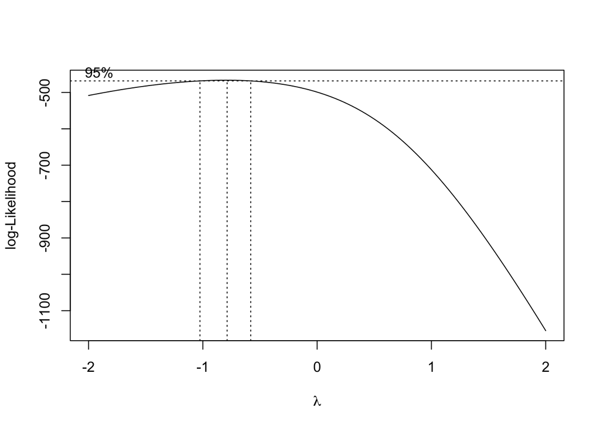

```r
wealth.df$region <- factor(wealth.df$region)

library(MASS)

wealth.lm <- lm(formula=wealth ~ age + region, data=wealth.df)
wealth.bcox <- boxcox(object=wealth.lm)
```

```r
wealth.bcox$x[wealth.bcox$y == max(wealth.bcox$y)]
```

```
## [1] -0.7878788
```

2. Test to see if the model is useful in explaining wealth. Show all steps.  
   **Solution**

```r
wealth.df$wealth_transform <- wealth.df$wealth^(-0.75)
wealth.df$region <- relevel(x=wealth.df$region, ref="U") # mirrors solution
boxcox.lm <- lm(formula=wealth_transform ~ age + region, data=wealth.df)
summary(boxcox.lm)
```

```
##
## Call:
## lm(formula = wealth_transform ~ age + region, data = wealth.df)
##
## Residuals:
##      Min       1Q   Median       3Q      Max
## -0.56243 -0.19150  0.02348  0.17907  0.41562
##
## Coefficients:
##               Estimate Std. Error t value Pr(>|t|)
## (Intercept)  0.6815604  0.0790610   8.621 1.35e-15 ***
## age         -0.0009325  0.0011440  -0.815    0.416
## regionA     -0.0328367  0.0481275  -0.682    0.496
## regionE      0.0325506  0.0396444   0.821    0.413
## regionM     -0.0058481  0.0574878  -0.102    0.919
## regionO      0.0116714  0.0527459   0.221    0.825
## ---
## Signif. codes:  0 '***' 0.001 '**' 0.01 '*' 0.05 '.' 0.1 ' ' 1
##
## Residual standard error: 0.2317 on 219 degrees of freedom
##   (8 observations deleted due to missingness)
## Multiple R-squared:  0.01263,    Adjusted R-squared:  -0.009911
## F-statistic: 0.5603 on 5 and 219 DF,  p-value: 0.7303
```

3. Sketch the plot of wealth by age. Is there anything surprising in this plot? Does it agree with your conclusions in part (b)? Explain.  
   **Solution**

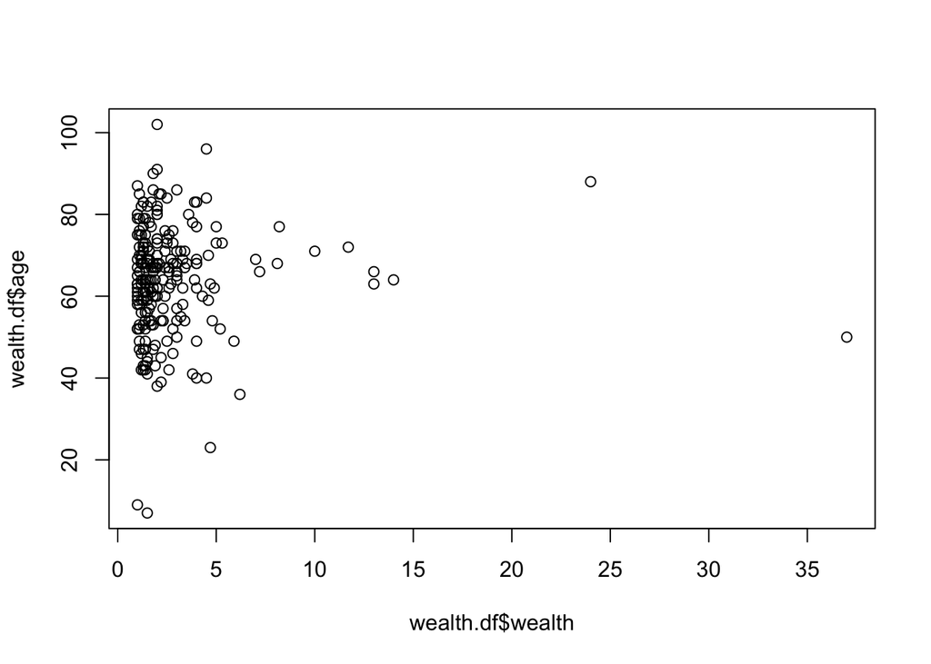

```r
plot(x=wealth.df$wealth, y=wealth.df$age)
```

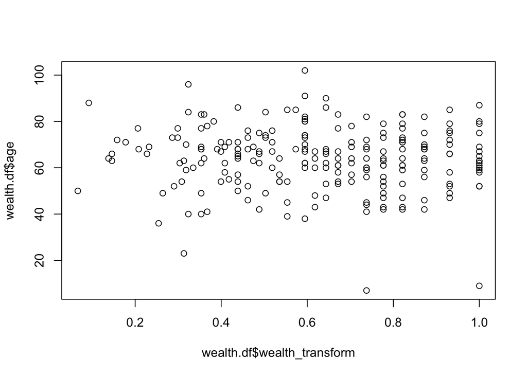

```r
plot(x=wealth.df$wealth_transform, y=wealth.df$age)
```

4. Test to see if there is a difference in average wealth between billionaires in Europe and Asia. Show all steps.  
   **Solution**

```r
eurasia.df <- wealth.df[wealth.df$region=="E" | wealth.df$region=="A", ]
eurasia.aov <- aov(formula=wealth_transform ~ region, data=eurasia.df)
summary(eurasia.aov)
```

```
##              Df Sum Sq Mean Sq F value Pr(>F)
## region        1  0.132 0.13171   2.842 0.0945 .
## Residuals   116  5.376 0.04634
## ---
## Signif. codes:  0 '***' 0.001 '**' 0.01 '*' 0.05 '.' 0.1 ' ' 1
```

5. Test to see if there is a significant difference in the number of billionaires among all regions. Show all steps.  
   **Solution**

```r
counts <- c(sum(wealth.df$region=="A"), sum(wealth.df$region=="E"), sum(wealth.df$region=="M"), sum(wealth.df$region=="U"), sum(wealth.df$region=="O"))

expected <- sum(counts)*.2
chi.ts <- sum((counts - expected)^2/expected)
pchisq(q=chi.ts, df=5-1, lower.tail=FALSE)
```

```
## [1] 1.627399e-10
```

```r
chisq.test(x=counts)
```

```
##
##  Chi-squared test for given probabilities
##
## data:  counts
## X-squared = 51.6567, df = 4, p-value = 1.627e-10
```